# Section 5.1 Comparing Two Groups: Categorical

Last updated Wednesday, April 30, 2025 @ 06:19 PM

## Before We Begin…

These slides are meant to accompany the text [*Introduction to Statistical Investigations, 2nd Edition*](http://www.isi-stats.com/isi/index2nd.html) — Section 5.1 Comparing Two Groups: Categorical Response.

*This content does not replace reading the relevant textbook section.* It is for class presentation, review, and reference.

See [AsULearn](https://asulearn.appstate.edu/) for additional readings, videos, and assignments.

You can print these slides to a pdf for offline use using the print function in your browser.

These slides include supplemental content about the measures percent increased risk, odds, and odds ratio that is not found in Section 5.1 of the ISI textbook.

## Recall: The Six-Step Spiral Process

- In Chapters 1 through 4, our research questions usually involved a single proportion parameter \(\pi\).
- In Chapter 5 we will look at comparing parameters for two groups (\(\pi_1, \pi_2\)).
- The investigative process is the same—the six-step “spiral” from Section P.1.
- Now \(H_0\) will be written as a *difference* in parameters.

## Learning Goals for Chapter 5

Chapter 5 extends what we learned about statistical significance in previous chapters to compare two groups with parameters \(\pi_1\) and \(\pi_2\). In this case, rather than testing a null hypothesis about whether \(\pi\) is equal to some value, we will typically have a null of *no difference*, written as \(H_0: \pi_1 = \pi_2\) or \(H_0: \pi_1 - \pi_2 = 0\).

We can also estimate the size of difference between \(\pi_1\) and \(\pi_2\).

- Compare two sample proportions numerically and graphically. [Section 5.1]
- Carry out a simulation-based analysis to investigate the difference between two population proportions. [Section 5.2]

We will *not* cover Section 5.3, regarding theory-based inference.

## Learning Goals for Section 5.1

- Organize counts into a two-way table, when data are available on two categorical variables for the same set of observational units.
- Calculate conditional proportion of successes, for different categories of the explanatory variable, and use these conditional proportions to decide whether there is preliminary evidence of an association between the explanatory and response variables.
- Create a segmented bar chart or mosaic plot to display data available on two categorical variables for the same set of observational units.
- Calculate and interpret risk ratio (also known as relative risk).

## Added Learning Goals (*Not in ISI Book*)

- Calculate and interpret percent increased risk.
- Calculate and interpret odds.
- Calculate and interpret odds ratio.

These summary values, along with risk ratio (relative risk) are used to compare the sizes of two conditional proportions. We could also use them as alternative test statistics.

The terms *relative risk*, *increased risk*, *odds*, and *odds ratio* are commonly found in published research literature, especially in health care studies. Odds ratios are also used with some more advanced analysis methods, such as logistic regression.

## Section 5.1 New Vocabulary

- cells
- conditional proportion
- percent increased risk *
- mosaic plot
- no association
- odds *
- odds ratio *
- relative risk *
- segmented bar graph
- two by two (2 × 2) table
- two-way table

**two-way table :** a tabular summary of two categorical variables, also called a contingency table

**two by two (2 × 2) table :** a two-way table where the explanatory and response variables each have two categories

**cells :** the individual entries in a two-way table that show where the two variables intersect (usually not including the row and column totals)

**conditional proportion :** the proportion of successes for a given category of the explanatory variable, or its **probability**; in some contexts (e.g., health care literature) this value may be called the **absolute risk** for the given category

**no association :** a general statement of the null hypothesis when two or more variables are involved, indicating that two variables are not related to each other

## Example: Survival Associated with Sex?

Consider the probability of survival for women and men aboard the infamous ship Titanic. In this case, sex (male, female) is the explanatory variable and whether or not the person survived is the response variable.

[output not shown]

Does it look like a passenger’s survival may have been related to (*associated with*) their sex?

**segmented bar graph :** a type of graph display for conditional proportions from a two-way table, with equal-width rectangles totaling 1 (100%) for each category of the explanatory variable; each bar is then split up by the conditional proportions for the categories of the response variable

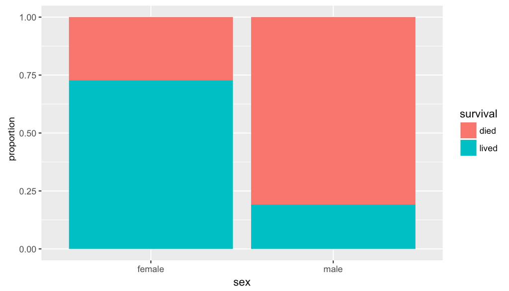

Survival Rates for Titanic Passengers by Sex

An example with three variables: sex, survival, and ticket class. Does ticket class seem to be associated with sex and survival? Look at the different survivor proportions between the graphs. Which *sex* and *ticket class* had the greatest survival probability?

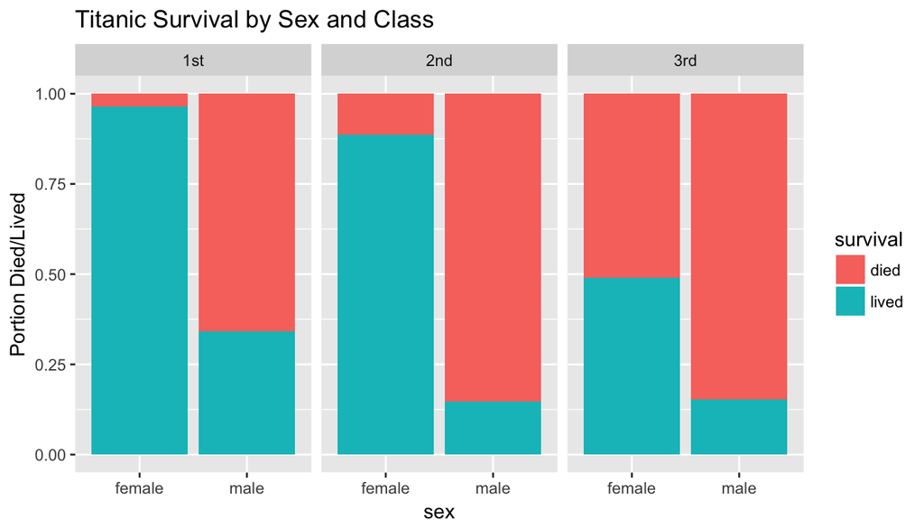

Survival Rates for Titanic Passengers by Sex and Class

**mosaic plot :** a segmented bar plot where the widths of the bars are proportional to the sample size

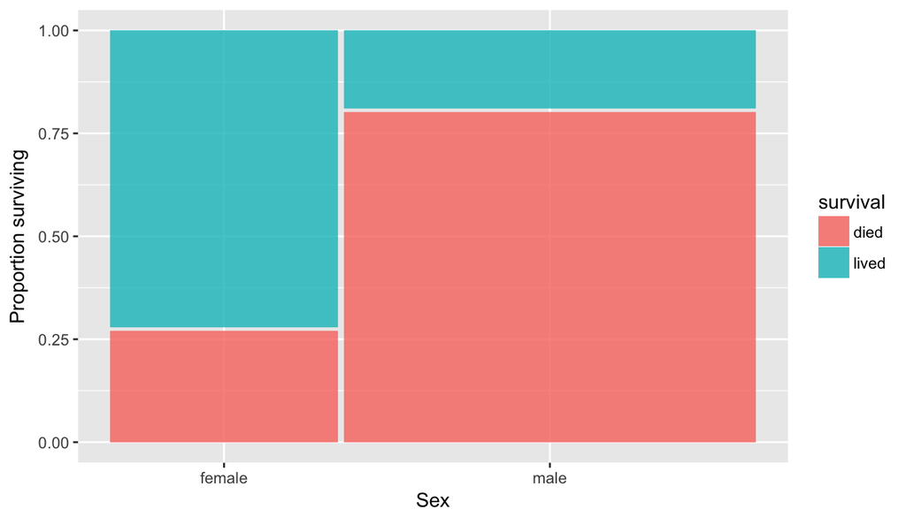

Survival Rates for Titanic Passengers by Sex

**relative risk :** the **ratio** of conditional proportions that indicates how many times greater the risk of some observed outcome is for one group, as compared to the risk of the same outcome in another group (also sometimes called **risk ratio**)

\[RR = \frac{\text{proportion (risk) in explanatory category 2}}{\text{proportion (risk) in explanatory category 1}}\]

Which group we call Category 1 and which group is Category 2 depends on the problem context. If we have a control group or “baseline” group for comparison in our study, that group usually will go in the denominator (i.e., on the bottom of the fraction).

Essentially, **risk** is another word for **probability** or proportion. In everyday English, we usually associate the word “risk” with some kind of bad outcome. However, in statistics we can use the term risk for any outcome we are interested in.

## Example: Risk of Oral Cancer

[Oral cancer](https://www.nidcr.nih.gov/health-info/oral-cancer) is a family of malignancies that includes cancers of the mouth and the back of the throat. Smoking and alcohol use, as well as sun exposure and poor nutrition, are some of the factors that have been found to be associated with this type of cancer. Consider the incidence of oral cancer among a group of smokers and non-smokers. *Smoking is the explanatory variable.*

| Oral Cancer? | Smoker | Non-Smoker |
| --- | --- | --- |
| Yes | 484 (56%) | 27 (23%) |
| No | 385 (44%) | 90 (77%) |
| Total | 869 (100%) | 117 (100%) |

We can calculate the relative risk or risk ratio.

\[RR = \frac{\text{oral cancer risk for smokers}}{\text{oral cancer risk for non-smokers}} = \frac{0.56}{0.23} = 2.43\]

According to the data, those who smoke are *2.43 times as likely* to develop oral cancer as those who do not smoke.

\[RR = \frac{\text{oral cancer risk for non-smokers}}{\text{oral cancer risk for smokers}} = \frac{0.23}{0.56} = 0.41\]

The decimal value 0.41 is about 2/5, so we can say non-smokers are about *two-fifths as likely* to develop oral cancer as smokers.

These are equivalent expressions, but the first version might be more understandable. We just need to be clear how the groups are being compared when stating risk ratios.

**percent increased risk :** this quantity re-expresses the absolute difference in risks as a fraction of the “baseline” risk

\[\%IR = \frac{\text{risk in category 2 - risk in category 1}}{\text{risk in category 1}} \times 100\%\]

We can also write this as a function of relative risk. First…

\[= \bigg( \frac{\text{risk in category 2}}{\text{risk in category 1}} - \frac{\text{risk in category 1}}{\text{risk in category 1}} \bigg) \times 100\%\]

Which simplifies to…

\[\%IR = (RR - 1) \times 100\%\]

*Example:* Revisit the incidence of oral cancer among smokers and non-smokers (*smoking is still the explanatory variable*).

If we let non-smokers be Category 1…

\[\%IR = \frac{0.56 - 0.23}{0.23} \times 100\% = 143\%\]

The percent *change* or *increase* in the risk of oral cancer is 143% for smokers as compared to non-smokers (i.e., the risk went up by 143% of the original 23% probability; 23% + 1.43(23%) = 56%).

What if we reverse the two groups?

\[\%IR = \frac{0.23 - 0.56}{0.56} \times 100\% = -59\%\]

A negative percent increased risk is a *decrease*. This should make sense—the risk of oral cancer is decreased if someone does *not* smoke, relative to smokers. In this case, risk decreases by more than half, from 56% down to 23%.

**odds :** odds is similar to probability (risk), except that instead of looking at the fraction of times an event occurs out of the whole, odds is a ratio of how often an event happens versus how often it does not happen

*Example 1:* The odds of getting a head versus a tail on a coin flip are 1:1 (for every 1 time a head occurs, we would expect 1 tail)

*Example 2:* The odds of rolling 6 on a standard die are 1:5, since there are five outcomes that are not a 6 (i.e., 1 through 5)

*Example 3:* In the oral cancer example, odds of a smoker getting oral cancer are 484 to 385. If we divide both sides by the smaller number, the odds are about 1.26 to 1 — for every 1 smoker who does not get oral cancer, about 1.26 will.

For the non-smokers, odds of getting cancer are 27 to 90 or 1 to 3.33. For every 1 nonsmoker who gets cancer, 3.33 will not.

**odds ratio :** odds ratio is similar to risk ratio, except using odds instead of risks; the odds are expressed as fractions in this case

\[OR = \frac{\text{odds in explanatory category 2}}{\text{odds in explanatory category 1}}\]

*Example:* What is the odds ratio of oral cancer among smokers versus nonsmokers? Turn the yes/no values into fractions.

\[OR = \frac{\text{yes for smokers}/\text{no for smokers}}{\text{yes for non-smokers}/\text{no for non-smokers}}\]

\[= \frac{484/385}{\text{27/90}} = 4.2\]

The odds of oral cancer among smokers is *4.2 times* the odds of oral cancer among non-smokers.

## Interpreting Measures

So what is a large relative risk, percent increased risk, odds, or odds ratio? *Let’s explore…*

Suppose the two probabilities being compared are the same. Let’s choose 0.25 for both as an example.

\[RR = \frac{\text{risk in explanatory category 2}}{\text{risk in explanatory category 1}} = \frac{0.25}{0.25} = 1\]

When the two probabilities are the same, their risk ratio is 1, so probability in one group is *one times* the probability in the other.

The more difference there is between the two probabilities, the farther from 1 the relative risk value will get. Possible values for relative risk are 0 to \(\infty\)—*never* negative.

\[\%IR = \frac{\text{risk2 - risk1}}{\text{risk1}} \times 100\% = \frac{.25 - .25}{.25} \times 100\% = 0\%\]

If two probabilities are equal, there is zero increase or decrease. The largest possible decrease is \(-100\%\) (Risk 2 is 0, so all of the risk is gone), while increase can technically be as large as \(\infty\).

\[OR = \frac{\text{odds in explanatory category 2}}{\text{odds in explanatory category 1}} = \frac{.25/.75}{.25/.75} = 1\]

When the two probabilities are the same, their odds ratio is 1, as we saw with relative risk.

Like relative risk, values for odds ratio (OR) can range between 0 and \(\infty\)—*never* negative.

## Back to Titanic

Consider again the survival of women versus men on Titanic.

[output not shown]

A test of significance, which we will learn in Section 5.2, would show that these two variables are associated, *p*-value < 0.0001. (Note: *This is observational data, so we cannot assume cause and effect. Ticket class is a confounding variable.*)

## Relative and Increase Risk

Women passengers were about three and a half times as likely to survive the sinking of the Titanic as men.

Women had about a 250% increased chance of survival vs. men when the Titanic sank.

Odds for women are 343 (*survivors*) vs. 127 (*fatalities*), which is 2.7 to 1 (*if we divide both counts by the smaller value 127*), so 2.7 women survived for each 1 woman that did not.

*Why the difference? It may have been a “women and children” first policy for loading lifeboats, or having a large fraction of male third class passengers and crew, other social norms, or the ship layout…*

## Another Perspective

[figure not shown]

A web site aimed at medical students who are prepping for the Step 1 Medical Board Exam includes a summary of [risk vs. odds](https://www.stomponstep1.com/odds-ratio-relative-risk-calculation-definition-probability-odds/) (*ignore the part about clinical trials vs. cohort studies*).